# Child Doc 4: Weight Data

Grace Rubin

2025-01-17

## 2.c. Overview

## 2.c.i. Longitudinal Changes in Body Weight

### Comparing Hormone Groups

*NOTE:* The longitudinal visualizations below reflect actual recorded weight. No corrections were made for cecal mass.

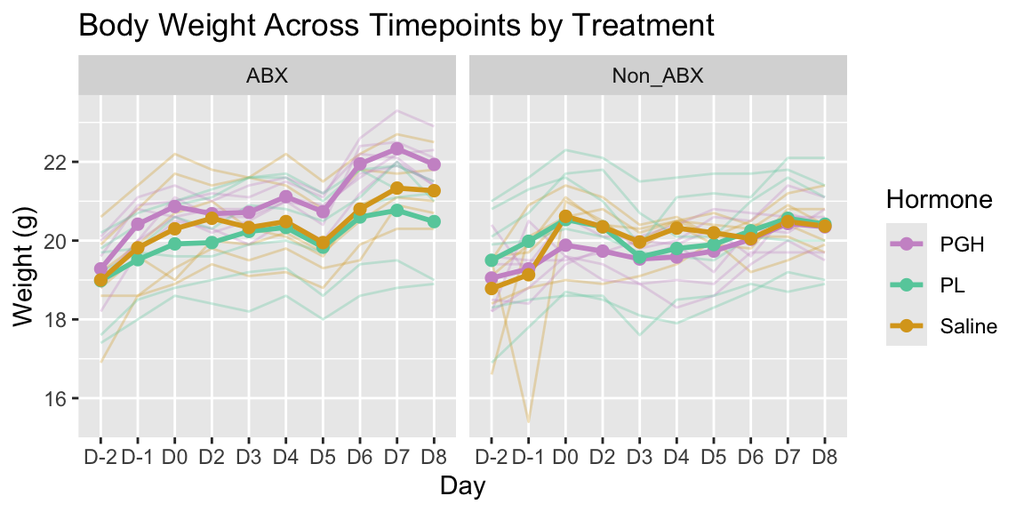

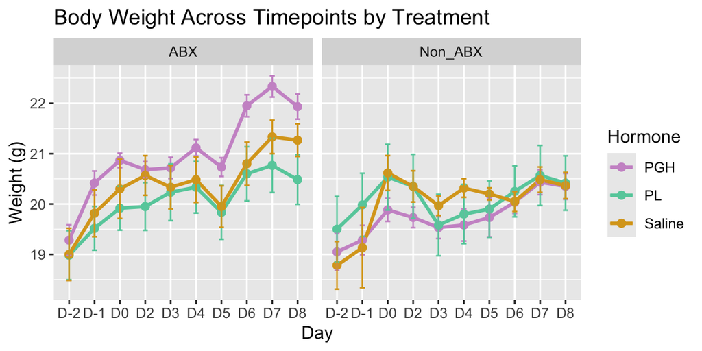

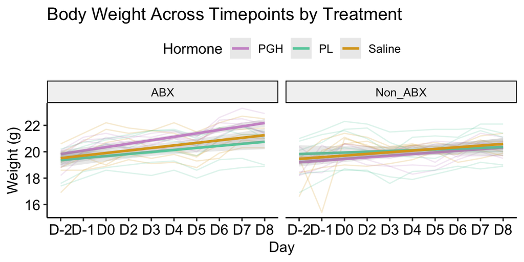

### Comparing Antibiotic Groups

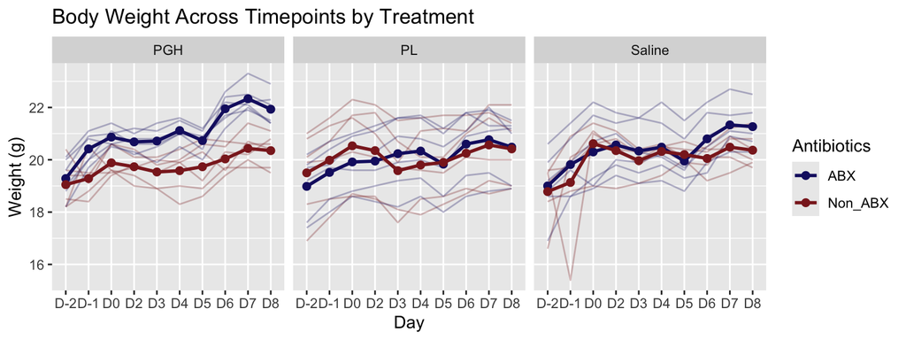

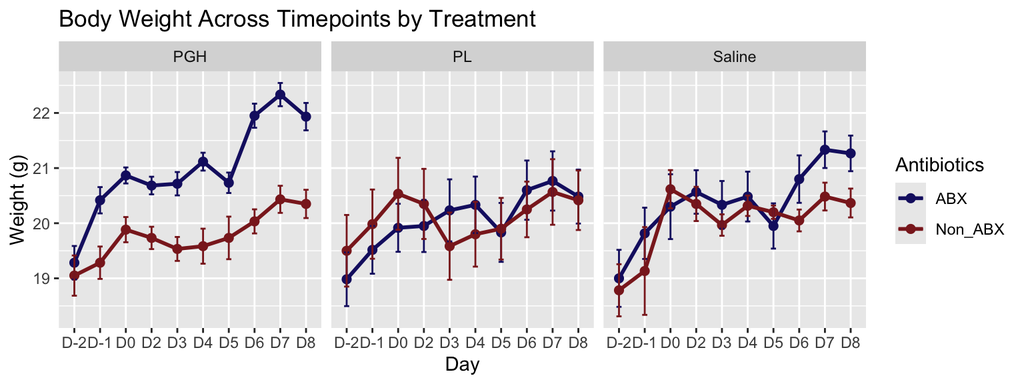

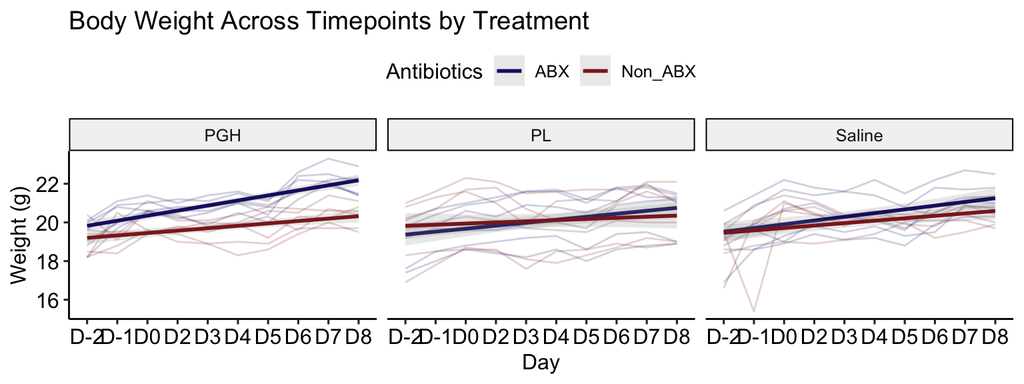

### Statistics

We can use LMEs to see if the rate of change in body mass is significantly different between different groups.

First let’s see within the Non-ABX mice if hormone affects the rate:

Though they don’t look visually distinct to me, some points are significant.

- At Days 0 and 4, there is a significant difference between PGH and Saline. Day 2 is also approaching significance (p = 0.0567).
- At Days 3, 4, and 5, Weight gain rates in PL and Saline are significantly different.

Next let’s see within the ABX mice if hormone affects the rate:

- There is a significant difference between PGH and Saline at Days 6 and 7. Day 5 is also approaching significance (p = 0.066).
- There is a significant difference between PL and Saline at Days 2, 7, and 8

Now we can see within each hormone group if the Non_ABX and ABX mice significantly differ in weight gain rates (remembering that these LMEs are not considering cecal mass).

As a simple non-interaction fixed effect, antibiotics affects weight gain in pgh mice (p = 0.001). As an interaction effect, antibiotics are significant at every day.

As a simple non-interaction fixed effect, antibiotics do not significantly affect weight gain in pl mice.

As an interaction effect, the weight gain slopes significantly differ at days 3, 4, 6, 7, and 8.

As a simple non-interaction fixed effect, antibiotics do not significantly affect weight gain in saline mice.

As an interaction effect, the weight gain slopes do not significantly differ at any days.

## 2.c.ii. Endpoint differences in Body Weight

By D8, we can assume that cecum mass is contributing significantly to body weight in the antibiotic mice. For these endpoint comparisons, we will calculate them both corrected for cecal mass and uncorrected. I’m subtracting by full cecal mass rather than cecal contents, because the effect of abx on the mass of the cecal epithelium also seems worth correcting for to me. But I could easily switch this to cecal contents!

### Comparing Hormone Groups

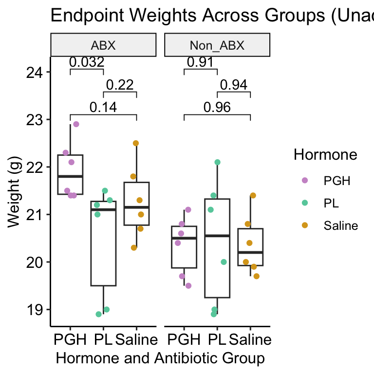

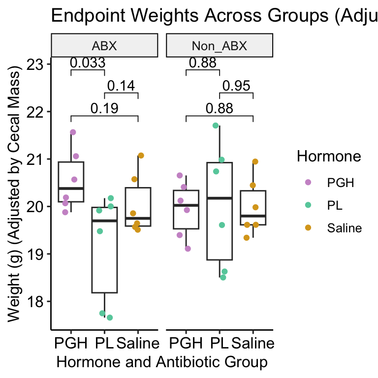

### Comparing Antibiotic Groups

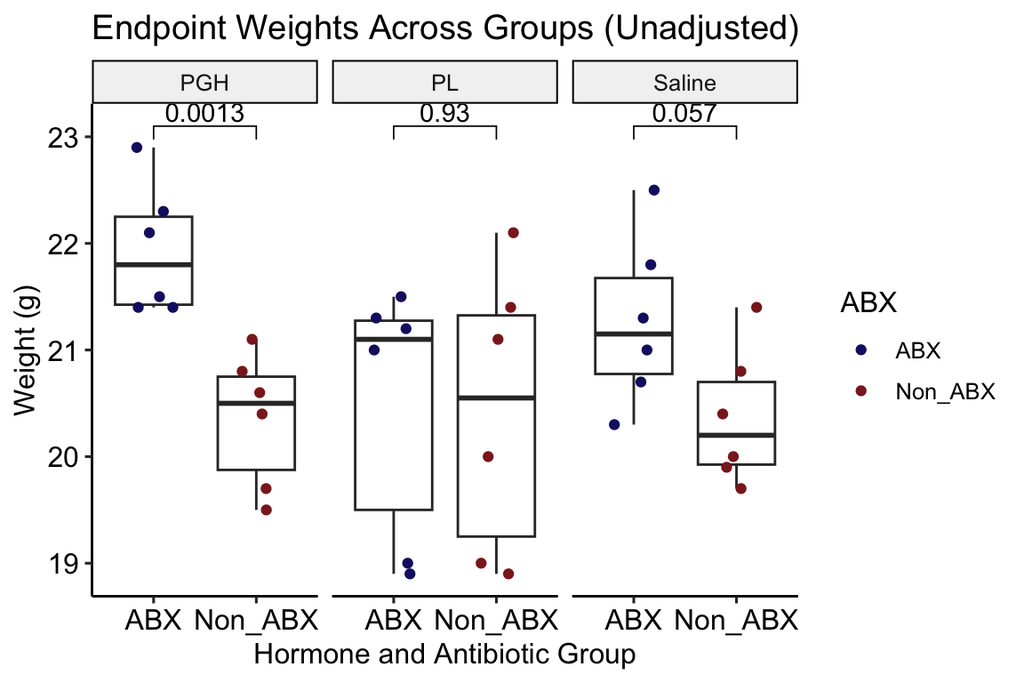

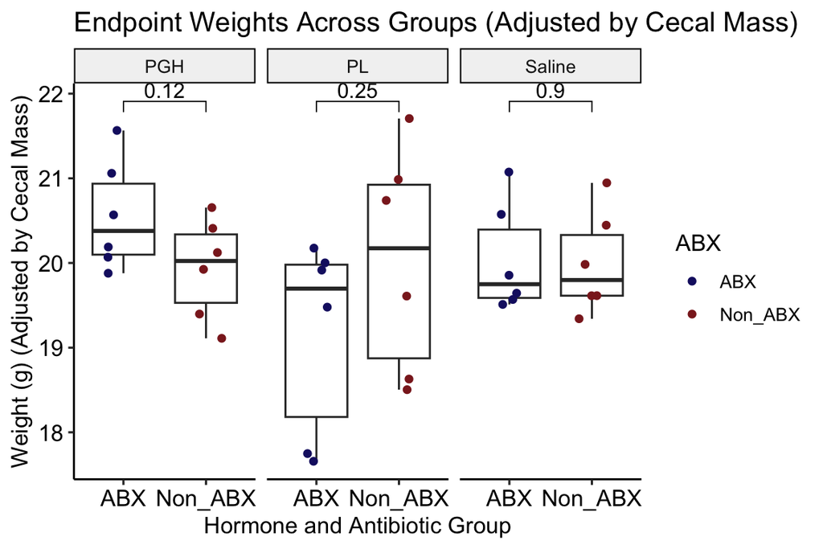